# Resampling Methods

- 필요 패키지 : `ISLR`, `boot`
- 필요 데이터 : `Auto{ISLR}`
- 주요 함수 : `sample{base}`, `cv.glm{boot}`

## 재표본기법 (Resampling methods)

- 적합된 모형에 대한 정보를 얻기위해 훈련자료(training set)로부터 샘플을 **반복적으로 추출**하여 해당 모형을 재적합하는 방법
  - **모형평가(Model Assessment)** : test error rates의 추정
  - **모형선택(Model Selection)** : 모형의 자유도(flexibility)를 선택
- 이 방법은 많은 계산량을 요구하지만 컴퓨팅의 발전으로 보편화 됨
- 재표본기법의 사용예
  - **Crossvalidation** : 모형 선택, 조절모수(tuning parameter) 선정
  - **Bootstrapping** : 표준오차 추정, Bagging

### Validation Set Approach

- Test (not training) error rate이 가장 작은 모형을 찾는다고 가정
  - Test error rate은 모형을 적합하는데 사용되는 훈련자료(training set)와 독립인 자료에 대한 error rate임
  - 검증자료(test set)가 부가적으로 주어지지 않는 한 test error rate를 알 수 없음
  - Training set을 통해 얻은 training error rate은 test error rate과 매우 상이하므로 이는 test error rate를 대체할 수 없음
- 자료의 크기가 매우 큰 경우 간단한 방법
  - **훈련자료(training set)** 및 **평가자료(validation set)** 로 랜덤하게 데이터를 분할
  - 각 가능한 모형들을 **훈련자료**에 적합하고, 이를 각기 **평가자료**에 적용하여 오차율을 계산하여 가장 낮은 오차율을 보이는 모형을 선택

#### `Auto` 데이터 예제

```r
library(ISLR)
help(Auto)
str(Auto)
```

```
## 'data.frame':    392 obs. of  9 variables:
##  $ mpg         : num  18 15 18 16 17 15 14 14 14 15 ...
##  $ cylinders   : num  8 8 8 8 8 8 8 8 8 8 ...
##  $ displacement: num  307 350 318 304 302 429 454 440 455 390 ...
##  $ horsepower  : num  130 165 150 150 140 198 220 215 225 190 ...
##  $ weight      : num  3504 3693 3436 3433 3449 ...
##  $ acceleration: num  12 11.5 11 12 10.5 10 9 8.5 10 8.5 ...
##  $ year        : num  70 70 70 70 70 70 70 70 70 70 ...
##  $ origin      : num  1 1 1 1 1 1 1 1 1 1 ...
##  $ name        : Factor w/ 304 levels "amc ambassador brougham",..: 49 36 231 14 161 141 54 223 241 2 ...
```

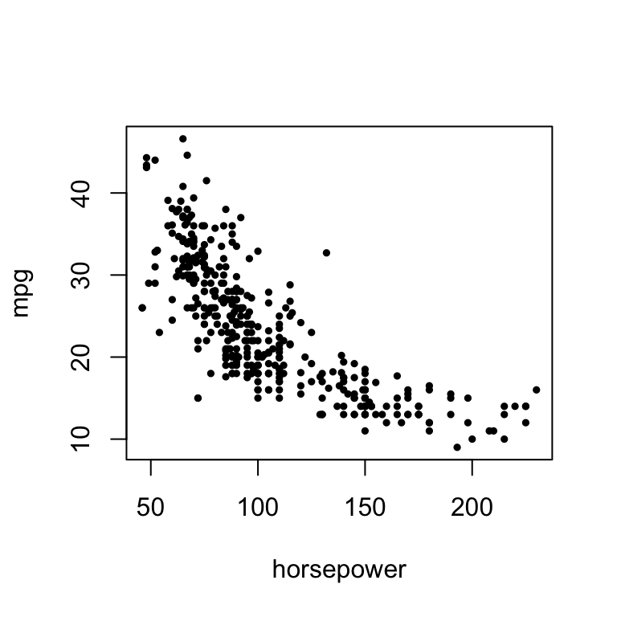

```r
plot(mpg ~ horsepower, data = Auto, cex = 0.5, pch = 19)
```

- 변수 `horsepower`로 `mpg`(연비)를 예측한다고 가정
- 다음의 다항회귀(polynomial regression) 모형을 고려 :
  - **mpg ~ horsepower**
  - **mpg ~ horsepower + horsepower$^2$**
  - **mpg ~ horsepower + horsepower$^2$ + … + horsepower$^p$**
- 모형선택 과정
  1. **훈련자료** (196개) 및 **평가자료** (196개)로 `Auto` 데이터를 랜덤하게 분할
  2. **훈련자료**를 사용하여 $p$개 모형을 적합
  3. 위에서 적합된 $p$개의 모형을 **평가자료**에 적용하여 모형을 평가 : **Mean Squared Error**(**MSE**)를 이용

  $$\text{MSE} = \frac{1}{n}\sum_{i=1}^n(y_i-\hat y_i)^2$$
  4. 평가자료 MSE가 가장 낮은 모형을 선택
- 특정 랜덤분할을 사용하여 얻은 평가자료 오차 (validation MSE)

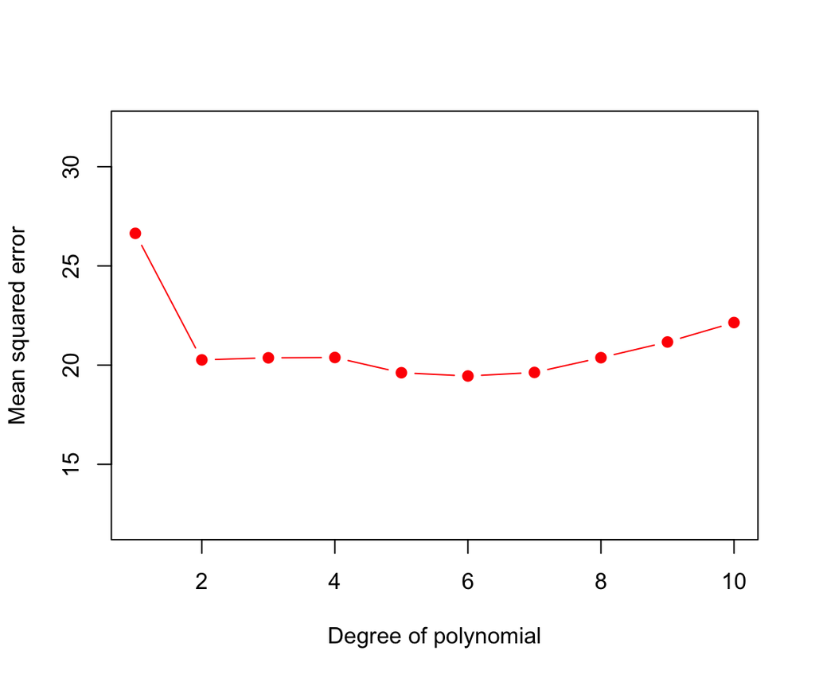

```r
set.seed(0)

N <- nrow(Auto)
tr <- sample(1:N, round(N/2), replace = FALSE)
Auto.tr <- Auto[tr,]
Auto.val <- Auto[-tr,]

mse <- rep(NA, 10)
for ( p in 1:10 ) {
  fit <- lm(mpg ~ poly(horsepower, p), data = Auto.tr)
  mse[p] <- mean((predict(fit, Auto.val) - Auto.val$mpg)^2)
}
plot(1:10, mse, type = "b", pch = 19, col = 2, ylim = c(12, 32),
     xlab = "Degree of polynomial", ylab = "Mean squared error")
```

- 랜덤분할을 10회 반복한 후, 각각에 대한 평가자료 오차
  - 분할 결과에 따라 MSE 값이 상당한 변동을 보임. 더 안정적인 방법이 필요

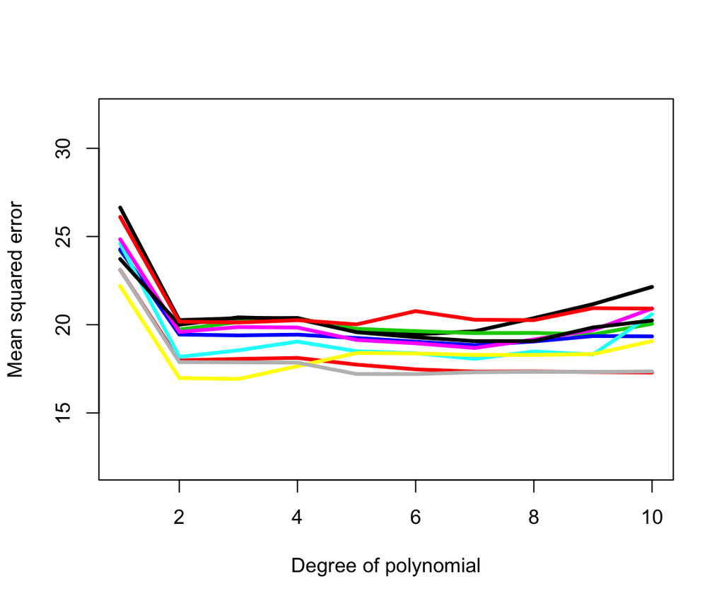

```r
plot(1:10, mse, type = "l", lwd = 3, ylim = c(12, 32),
     xlab = "Degree of polynomial", ylab = "Mean squared error")
for ( j in 2:10 ) {
  tr <- sample(1:N, round(N/2), replace = FALSE)
  Auto.tr <- Auto[tr,]
  Auto.val <- Auto[-tr,]
  mse <- rep(NA, 10)
  for ( p in 1:10 ) {
    fit <- lm(mpg ~ poly(horsepower, p), data = Auto.tr)
    mse[p] <- mean((predict(fit, Auto.val) - Auto.val$mpg)^2)
  }
  lines(1:10, mse, col = j, lwd = 3)
}
```

#### Validation Set Approach의 장단점

- 장점 :
  - **단순**하다
  - 실행이 **쉽다**
- 단점 :
  - 평가자료 MSE가 분할결과에 따라 **변동이 심하다** $\Rightarrow$ test MSE의 추정치로 사용이 부적당함
  - 사용가능한 **자료의 일부분만 훈련자료(training data)로 이용** $\Rightarrow$ 통계적 방법론은 적은 수의 자료를 이용하는 경우 성능이 저하

## Leave-One-Out Cross Validation (LOOCV)

- LOOCV는 Validation Set Approach와 유사하나 이에 대한 단점을 보완

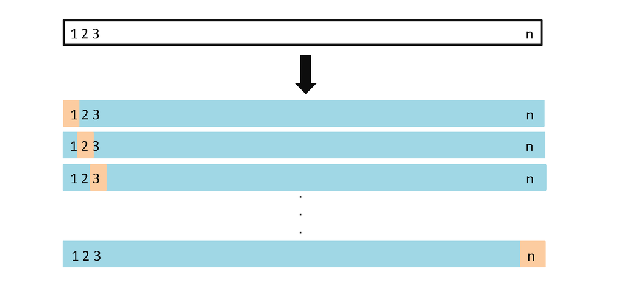

- 각 모형들에 대해 다음을 수행 :
  1. 크기 $n$인 자료를 다음과 같이 분할
     - **훈련자료**(파랑색) 크기 : **n-1**
     - **평가자료**(베이지색) 크기 : **1**
  2. 훈련자료를 사용하여 모형을 적합하고, 적합된 모형을 평가자료에 적용하여 MSE 계산
  3. 위 과정을 $n$회 반복
  4. cross-validated MSE는 다음과 같이 계산:

$$\text{CV}_{(n)} = \frac{1}{n}\sum_{i=1}^n\text{MSE}_i$$

### LOOCV와 Validation Set Approach의 비교

- **LOOCV는 편향(bias)이 적다**
  - $n-1$개의 훈련자료를 이용하여 통계방법을 반복적으로 적합 (거의 자료의 대부분을 활용하여 학습)
- **LOOCV을 통해 얻는 MSE는 훨씬 안정적이다**
  - Validation Set Approach는 분할과정에서 임의성(randomness)이 개입하므로 수행시마다 다른 MSE값이 계산됨. 반면, LOOCV는 임의성이 없으므로 동일한 MSE를 도출
- **LOOCV는 계산집약적(computatinally intensive)이다**
  - 하나의 모형을 위해 $n$회 반복 적합해야 함

## K-fold Cross Validation

- 계산집약적인 LOOCV를 보완하기 위해 **K-fold Cross Validation** (**K-fold CV**)을 사용

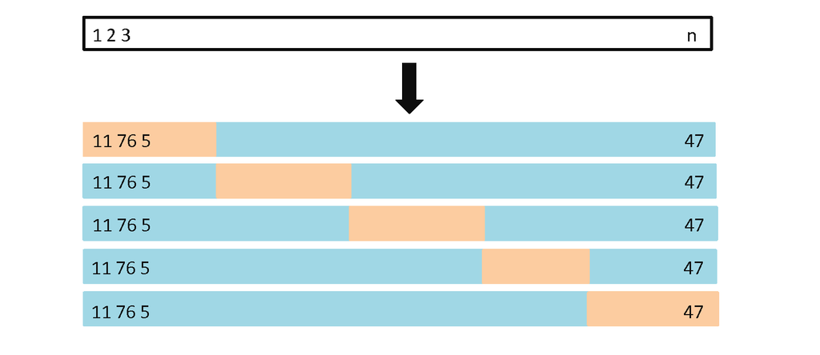

1. $K$ 부분으로 데이터셋을 랜덤하게 분할 (e.g., $K=5$, or $K=10$)
2. 첫번째 fold를 제외한 남은 $K-1$ fold (훈련자료)로 모형을 적합. 제외된 fold (평가자료)에 적합된 모형을 적용하여 MSE를 계산
3. 두번째 fold를 평가자료, 나머지 $K-1$ fold를 훈련자료로 하여 반복 수행. 이를 총 $K$회 반복한다
4. $K$개의 MSE의 평균으로 cross-validated MSE를 계산. 이를 새로운 관측값에 대한 test MSE의 추정치로 사용

$$\text{CV}_{(K)} = \frac{1}{K}\sum_{k=1}^K \text{MSE}_k$$

#### `Auto` 데이터 예제 : LOOCV 와 K-fold CV의 비교

- `Auto` 자료를 이용, 차수별 다항회귀모형에 대한 오차를 계산
- LOOCV

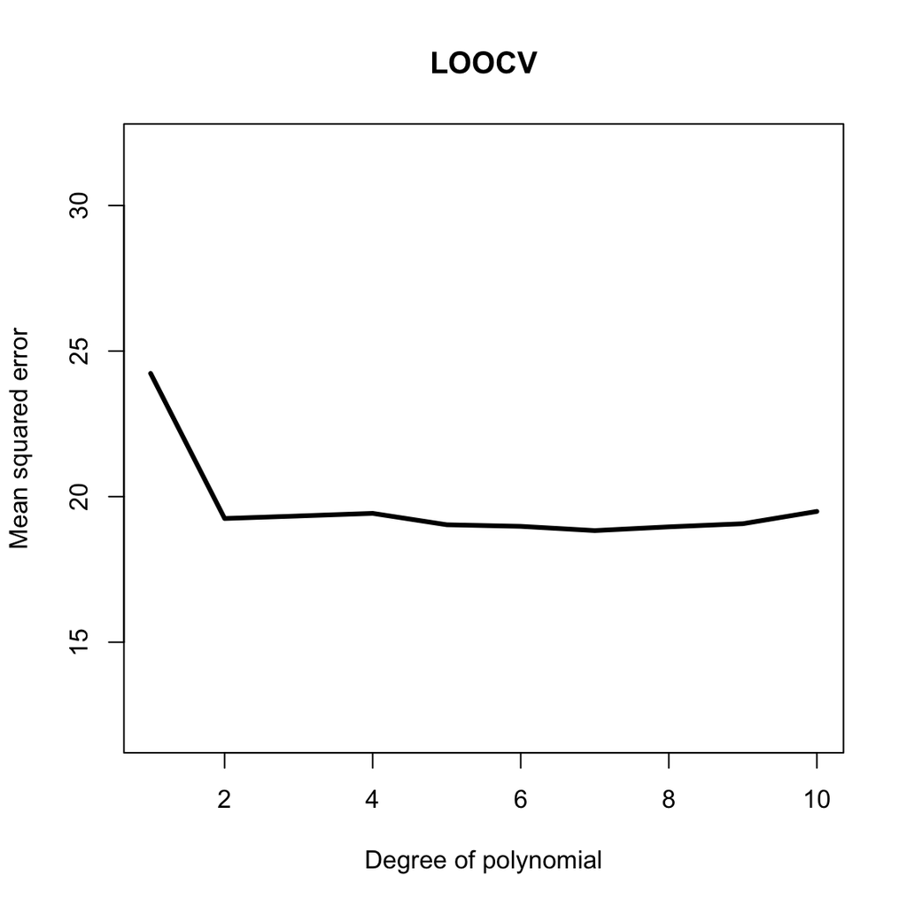

```r
mse <- rep(0, 10)
for ( p in 1:10 ) {
  for ( i in 1:N ) {
    tr <- Auto[-i,]
    te <- Auto[i,]
    fit <- lm(mpg ~ poly(horsepower, p), data = tr)
    mse[p] <- mse[p] + (predict(fit, te) - te$mpg)^2
  }
}
mse <- mse/N

plot(1:10, mse, type = "l", lwd = 3, ylim = c(12, 32), main = "LOOCV",
     xlab = "Degree of polynomial", ylab = "Mean squared error")
```

- K-fold CV

```r
set.seed(0)

K <- 10
M <- round(N/K)
V <- matrix(0, K, 2)
for ( k in 1:K ) {
  V[k,] <- c(M*(k - 1) + 1, min(M*k, N))
}

ind <- sample(1:N)
mse <- matrix(NA, K, 10)
for ( k in 1:K ) {
  val <- ind[V[k, 1]:V[k, 2]]
  tr <- ind[-(V[k, 1]:V[k, 2])]
  for ( p in 1:10 ) {
    fit <- lm(mpg ~ poly(horsepower, p), data = Auto, subset = tr)
    mse[k, p] <- mean((predict(fit, Auto[val,]) - Auto$mpg[val])^2)
  }
}
CV <- colMeans(mse)
print((1:10)[which.min(CV)])
```

```
## [1] 7
```

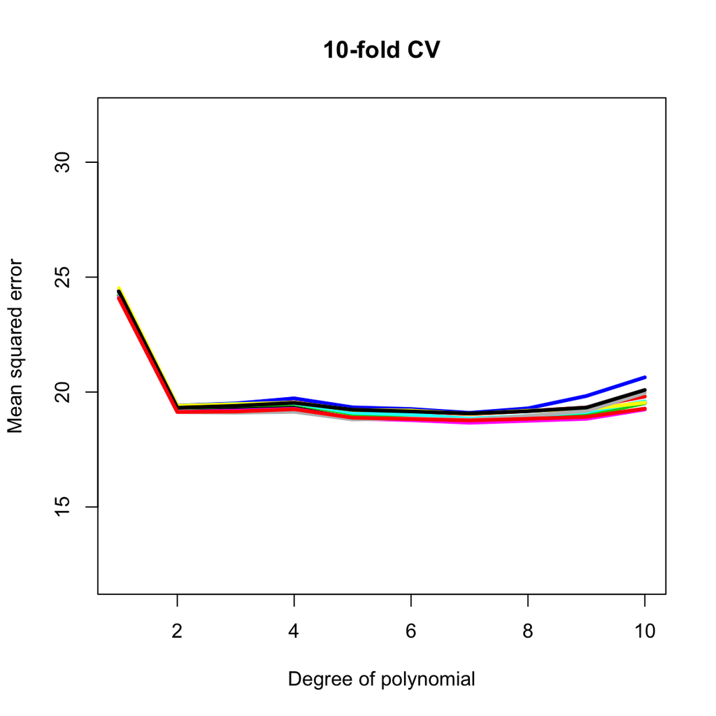

```
## [1] 7
## [1] 7
## [1] 7
## [1] 7
## [1] 7
## [1] 7
## [1] 7
## [1] 7
## [1] 7
```

```r
plot(1:10, CV, type = "l", lwd = 3, ylim = c(12, 32),
     main = paste(k, "-fold CV", sep = ""),
     xlab = "Degree of polynomial", ylab = "Mean squared error")

for ( j in 2:10 ) {
  ind <- sample(1:N)
  mse <- matrix(NA, K, 10)
  for ( k in 1:K ) {
    val <- ind[V[k, 1]:V[k, 2]]
    tr <- ind[-(V[k, 1]:V[k, 2])]
    for ( p in 1:10 ) {
      fit <- lm(mpg ~ poly(horsepower, p), data = Auto, subset = tr)
      mse[k, p] <- mean((predict(fit, Auto[val,]) - Auto$mpg[val])^2)
    }
  }
  CV <- colMeans(mse)
  print((1:10)[which.min(CV)])
  lines(1:10, CV, lwd = 3, col = j)
}
```

- `boot` 패키지 이용

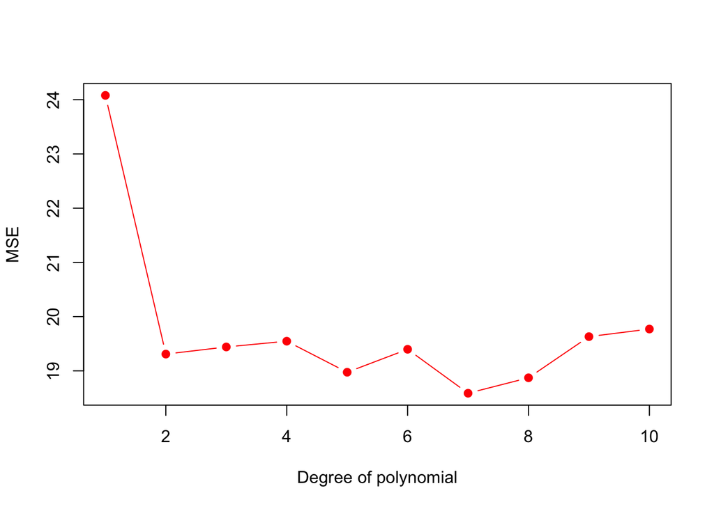

```r
library(boot)
set.seed(0)
cv <- rep(NA, 10)
for ( p in 1:10 ) {
  fit <- glm(mpg ~ poly(horsepower, p), data = Auto)
  cv[p] <- cv.glm(Auto, fit, K = 10)$delta[1]  # K를 지정하지 않으면 LOOCV
}
plot(1:10, cv, type = "b", col = 2, pch = 19,
     xlab = "Degree of polynomial", ylab = "MSE")
```

### Bias-Variance Trade-off for k-fold CV

- 편향-분산 균형적 관점에서의 비교
  - **LOOCV** 는 **K-fold CV** 보다 **편향이 적은 반면 분산이 큰 경향**이 있음
  - 그러므로, 둘 사이에는 trade-off가 존재
- **결론** :
  - 주로 K = 5, 혹은 10인 **K-fold CV** 사용
  - 경험적으로, K-fold CV를 통한 test MSE 추정량은 과도한 편향(bias)이나 큰 분산(variance)가 나타나지 않고 안정적임

## 분류문제에 대한 Cross Validation의 적용

- 분류문제의 경우 test error rate을 추정하기 위해 CV 사용 가능
  1. $K$ folds로 자료를 랜덤하게 분할
  2. 한 부분을 평가자료, 남은 부분을 훈련자료로 두어 훈련자료에서 적합된 모형을 평가자료에 적용하고 error rate를 계산
  3. $K$회 반복
  4. CV error rate은 $K$개의 오분류율의 평균으로 계산

### CV를 통한 로지스틱모형의 차수 결정 예제

- CV를 통해 로지스틱모형의 차수를 결정
  - 보라색 점선 : Bayes decision boundary
  - Bayes Error Rate (오분류율) : 0.133
  - Degree=1 : 선형 로지스틱회귀는 Bayes decision boundary 설명하지 못함
  - Degree=2 : 2차 로지스틱회귀는 선형보다 약간 향상되었으나 충분치 못함
  - Degree=3 : 3차 로지스틱회귀는 만족스런 추정을 줌
  - Degree=4 : 4차 로지스틱회귀 또한 만족스러우나 3차에 비해 비약적인 향상을 주지 못함

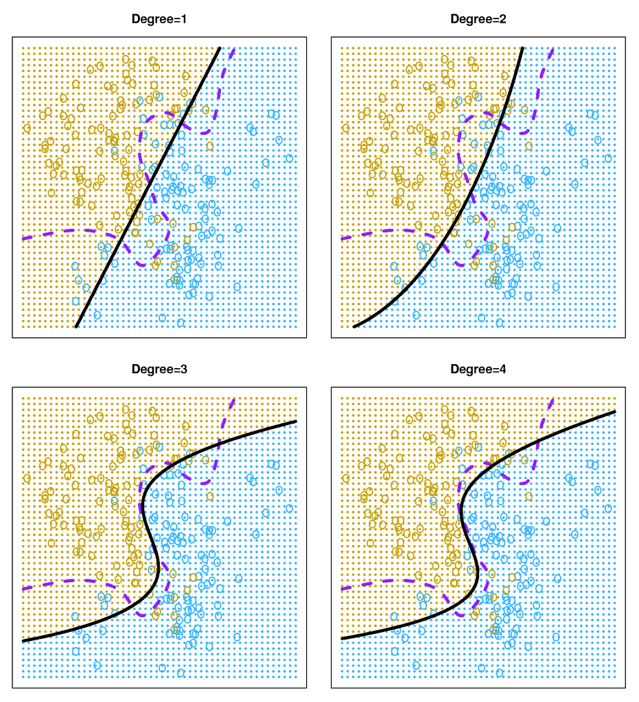

- CV를 활용한 차수의 결정
  - 최소 test 오분류율은 3차에서 결정되지만 최소 CV 오분류율은 4차에서 결정됨
    - 갈색 : test error rate
    - 파랑 : training error rate
    - 검정 : 10-fold CV error rate

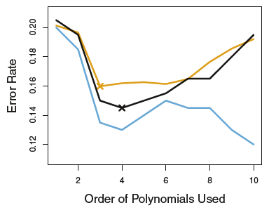

## Bootstrap

- 주어진 표본에서 얻은 추정량 혹은 통계모형의 성능 평가를 위한 측도를 구하는 것으로 응용범위가 매우 넓은 유용한 방법
- 추정치의 표준오차 계산, 신뢰구간 구축, 가설검정 등을 시행하는데 사용됨

### Motivating example: `Portfolio` 데이터

- 두 개의 금융자산의 수익률

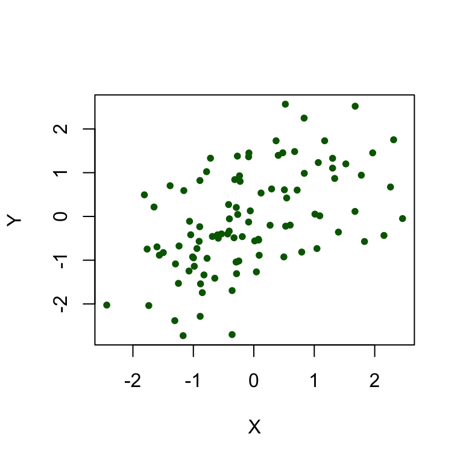

```r
library(ISLR)
plot(Portfolio, col = "darkgreen", pch = 20)
```

- 포트폴리오
  - 두 자산에 각각 $(\alpha, \,\,1-\alpha)$의 비율로 분산투자
  - 두 자산의 수익률을 각각 $X$, $Y$라 하면 분산투자의 결과로 얻는 수익률 $R$은 $R = \alpha X + (1-\alpha) Y$
- 최소분산포트폴리오
  - $\text{Var}(R)$을 최소로 하는 $\alpha$의 값
    $$\alpha^* = \frac{\sigma_Y^2 - \sigma_{XY}}{\sigma_X^2 + \sigma_Y^2 - 2\sigma_{XY}}$$
  - $\alpha$를 데이터를 이용해 추정

```r
MVP <- function(X, Y) (var(Y) - cov(X, Y))/(var(X) + var(Y) - 2*cov(X, Y))
print(alpha <- MVP(Portfolio$X, Portfolio$Y))
```

```
## [1] 0.5758321
```

- 데이터는 과거의 수익률을 기록한 것. 위에서 도출한 $\alpha$의 값을 미래의 투자 의사 결정에 반영할 때 감내해야 하는 불확실성을 계상하고 싶음.

### 절차

1. 주어진 데이터에 resampling(복원추출)을 적용해 어러 개($B$)의 데이터셋을 생성
2. 생성된 데이터를 이용해 $\alpha$ 값 추정
3. 2에서 얻은 $\alpha$ 값들을 이용해 $\alpha$의 불확실성 추론

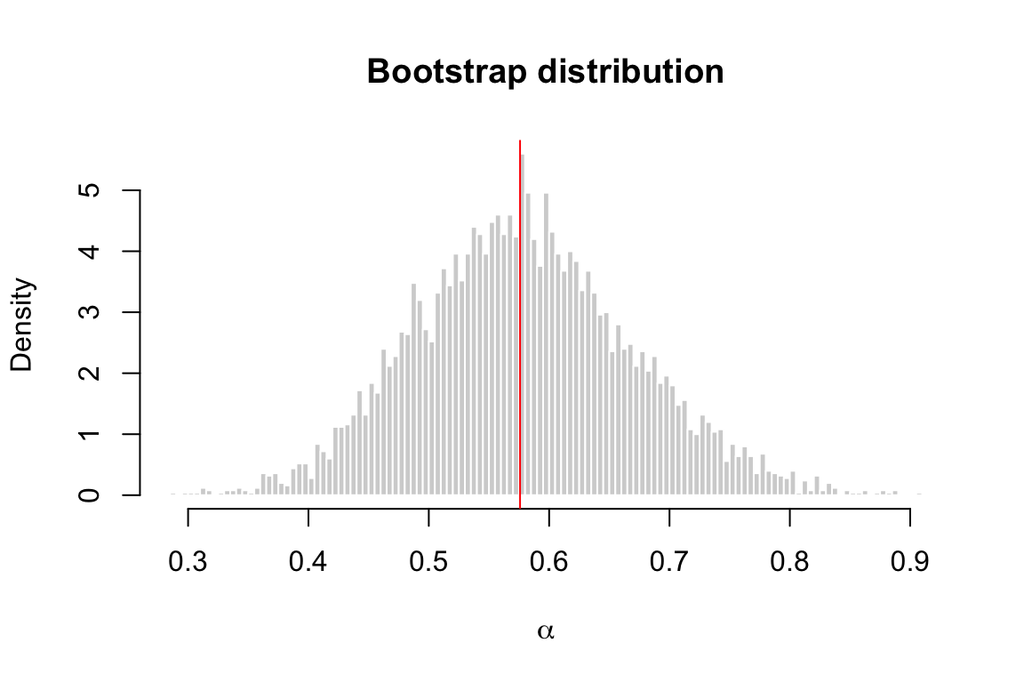

```r
set.seed(0)

B <- 5000
alpha.boot <- rep(NA, B)
N <- nrow(Portfolio)

for ( b in 1:B ) {
  Portfolio.boot <- Portfolio[sample(1:N, N, replace = TRUE),]
  alpha.boot[b] <- with(Portfolio.boot, MVP(X, Y))
}

hist(alpha.boot, probability = TRUE, xlab = expression(alpha),
     col = "lightgray", border = "white", nclass = 100,
     main = "Bootstrap distribution")
abline(v = alpha, col = 2)
```